# Projekt do předmětu Časové řady I

- Zobrazit celý kód
- Skrýt celý kód
- Zobrazit zdrojový kód

Autor

Michal Červenka, Martin Heger, Štěpán Husa

Publikováno

15. prosince 2025

# Úvod

## 1. Načtení knihoven

**Kód**

```r
# Načtení potřebných balíčků
if (!require(forecast)) install.packages("forecast", repos = "https://cloud.r-project.org")
if (!require(zoo)) install.packages("zoo")
if (!require(readr)) install.packages("readr", repos = "https://cloud.r-project.org")
if (!require(tseries)) install.packages("tseries", repos = "https://cloud.r-project.org")
library(readr)
library(zoo)
library(forecast)
library(tseries)
library(ggplot2)
library(dplyr)
library(tseries)
```

## 2. Načtení dat

**Kód**

```r
# Načtení datasetu
data <- read_csv("MLTollsStackOverflow.csv")
head(data[c("month", "python", "r")])
```

```
# A tibble: 6 × 3
  month  python     r
  <chr>   <dbl> <dbl>
1 09-Jan    631     8
2 09-Feb    633     9
3 09-Mar    766     4
4 09-Apr    768    12
5 09-May   1003     2
6 09-Jun   1046     5
```

## 3. Popis dat

Použitý dataset obsahuje měsíční počty dotazů na StackOverflow od roku 2009 do roku 2020 pro různé programovací knihovny a technologie. Pro účely této analýzy se zaměřujeme pouze na dvě proměnné – Python a R, které reprezentují počet dotazů souvisejících s těmito jazyky v jednotlivých měsících.

Nejprve jsme si zobrazili několik prvních pozorování datasetu, abychom se seznámili se strukturou dat a ověřili, že hodnoty odpovídají očekávanému formátu. Následně jsme vypočítali základní popisné statistiky pro obě časové řady.

### Popisné statistiky - Python & R

**Kód**

```r
# Popisné statistiky
summary(data[, c("python", "r")])
```

```
     python            r
 Min.   :  631   Min.   :   2.0
 1st Qu.: 3744   1st Qu.: 608.8
 Median : 9652   Median :2613.5
 Mean   : 9857   Mean   :2411.9
 3rd Qu.:15591   3rd Qu.:4000.5
 Max.   :23602   Max.   :5138.0
```

- Minimální počet dotazů je výrazně vyšší u Pythonu než u R.
- Medián i průměr jsou u Pythonu několikanásobně vyšší než u R, což naznačuje dlouhodobě větší popularitu Pythonu.
- Rozptyl hodnot je u Pythonu rovněž vyšší, což souvisí s rychlejším růstem zájmu v čase.
- Maximální hodnoty ukazují, že Python dosahuje až téměř 24 000 dotazů za měsíc, zatímco R přibližně 5 100.

# Analýza

## 1. Předběžný výzkum časové řady

### Grafické zobrazení časových řad

#### Python

**Kód**

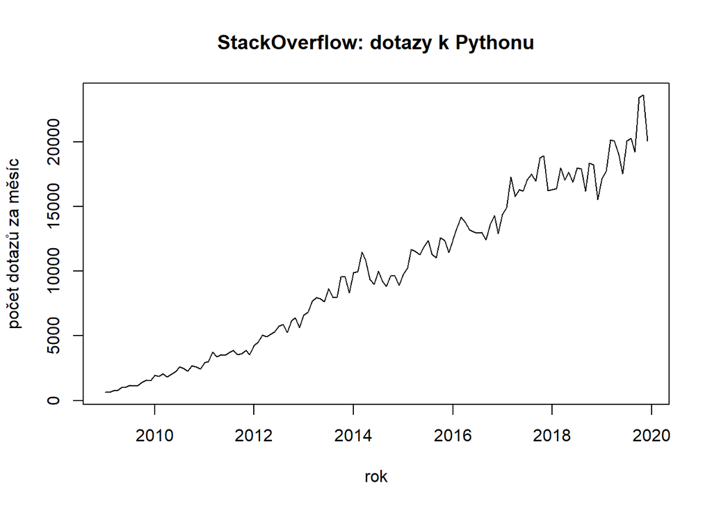

```r
# Vytvoření časové řady: Python
python_ts <- ts(data$python,
                start = c(2009, 1),
                #end = c(2015, 12),
                frequency = 12)

# Vytvoření časové řady: R
r_ts <- ts(data$r,
           start = c(2009, 1),
           #end = c(2015, 12),
           frequency = 12)

# Graf: Python
plot(python_ts,
     main = "StackOverflow: dotazy k Pythonu",
     ylab = "počet dotazů za měsíc",
     xlab = "rok")
```

- Jasný rostoucí trend od roku 2009 do 2020.
- Postupem času narůstá i variabilita počtu dotazů.
- Viditelné pravidelné sezónní kolísání.

#### R

**Kód**

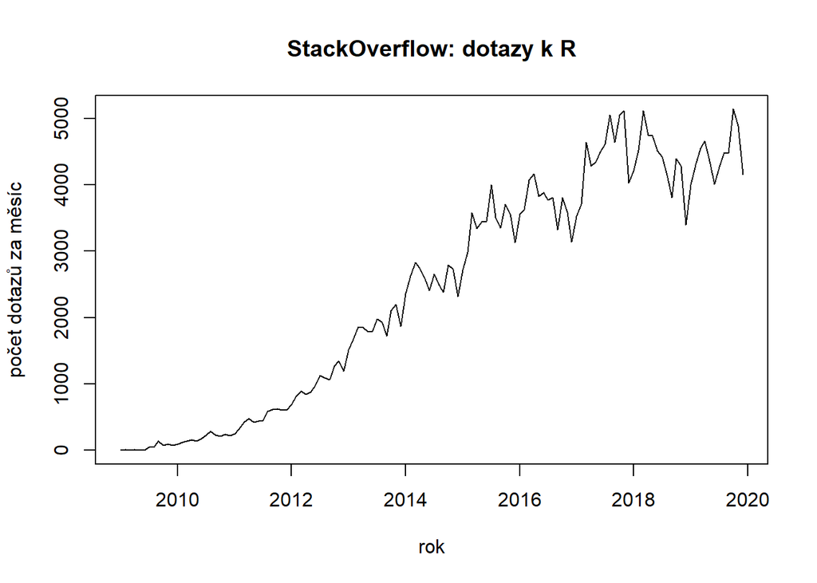

```r
# Graf: R
plot(r_ts,
     main = "StackOverflow: dotazy k R",
     ylab = "počet dotazů za měsíc",
     xlab = "rok")
```

- Trend také roste, ale pomaleji a méně výrazně než u Pythonu.
- Amplituda sezónnosti je menší.
- Po roce 2017 se růst zpomaluje.

#### Společný graf

**Kód**

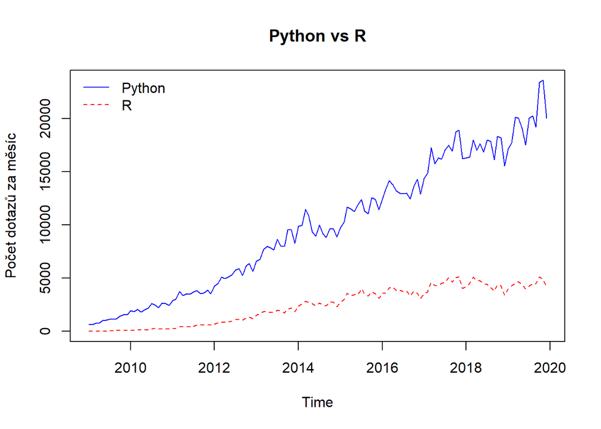

```r
# Společný graf
par(mfrow = c(1,1))


ts.plot(cbind(python_ts, r_ts),
        col = c("blue", "red"),
        lty = 1:2,
        main = "Python vs R",
        ylab = "Počet dotazů za měsíc")

legend("topleft",
       legend = c("Python", "R"),
       col = c("blue", "red"),
       lty = 1:2,
       bty = "n")
```

- Python má výrazně větší počet dotazů a rychleji roste.
- Od roku ~2014 se rozdíl ještě zvětšuje.
- Oba jazyky mají podobný vzor sezónnosti.

### Aditivní dekompozice

#### Python

**Kód**

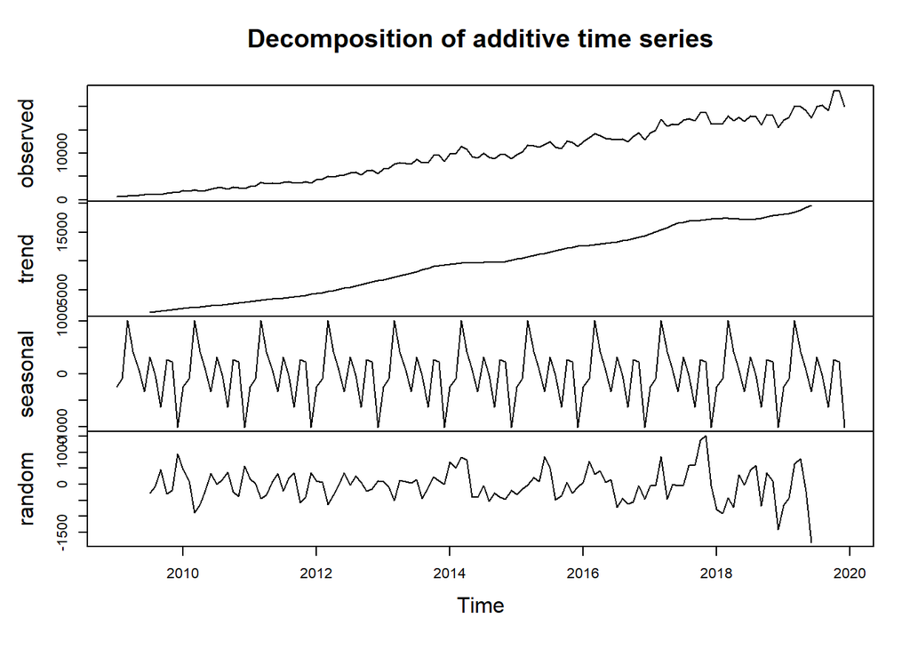

```r
# Additivní dekompozice

## Python
decomp_python <- decompose(python_ts, type = "additive")
plot(decomp_python)
```

- **Trend**: silně rostoucí, plynulý.
- **Sezónnost**: pravidelná, opakující se ročně.
- **Remainder**: náhodné fluktuace bez jasné struktury.

#### R

**Kód**

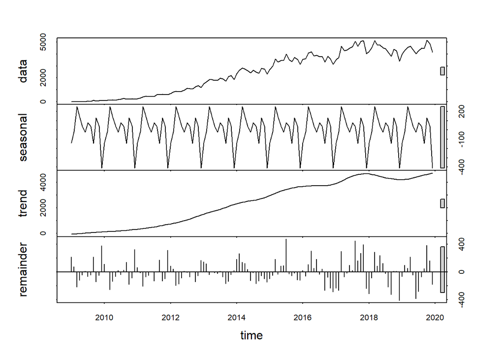

```r
## R
stl_r <- stl(r_ts, s.window = "periodic")
plot(stl_r)
```

- **Trend**: roste, ale méně než Python; kolem 2017 mírné zpomalení.
- **Sezónnost**: také pravidelná a stabilní.
- **Remainder**: náhodný šum bez výrazných anomálií.

## 2. Testování stacionarity

### Python

**Kód**

```r
adf_python <- adf.test(python_ts)
adf_python
```

```
    Augmented Dickey-Fuller Test

data:  python_ts
Dickey-Fuller = -3.1904, Lag order = 5, p-value = 0.09258
alternative hypothesis: stationary
```

### R

**Kód**

```r
adf_r <- adf.test(r_ts)
adf_r
```

```
    Augmented Dickey-Fuller Test

data:  r_ts
Dickey-Fuller = -1.8242, Lag order = 5, p-value = 0.6496
alternative hypothesis: stationary
```

### Python - diference

**Kód**

```r
adf_python_diff <- adf.test(diff(python_ts))
adf_python_diff
```

```
    Augmented Dickey-Fuller Test

data:  diff(python_ts)
Dickey-Fuller = -6.1661, Lag order = 5, p-value = 0.01
alternative hypothesis: stationary
```

### R - diference

**Kód**

```r
adf_r_diff  <- adf.test(diff(r_ts))
adf_r_diff
```

```
    Augmented Dickey-Fuller Test

data:  diff(r_ts)
Dickey-Fuller = -5.9925, Lag order = 5, p-value = 0.01
alternative hypothesis: stationary
```

**Shrnutí**:

- Obě časové řady jsou nestacionární v původní podobě.
- Důvodem je především rostoucí trend a možná sezónnost.
- Obě řady se stávají stacionární po jedné diferenci.
- Pro modelování ARIMA bude nutné řady diferencovat (parametr d = 1).

## 3. Autokorelace a parciální autokorelace

### Python

**Kód**

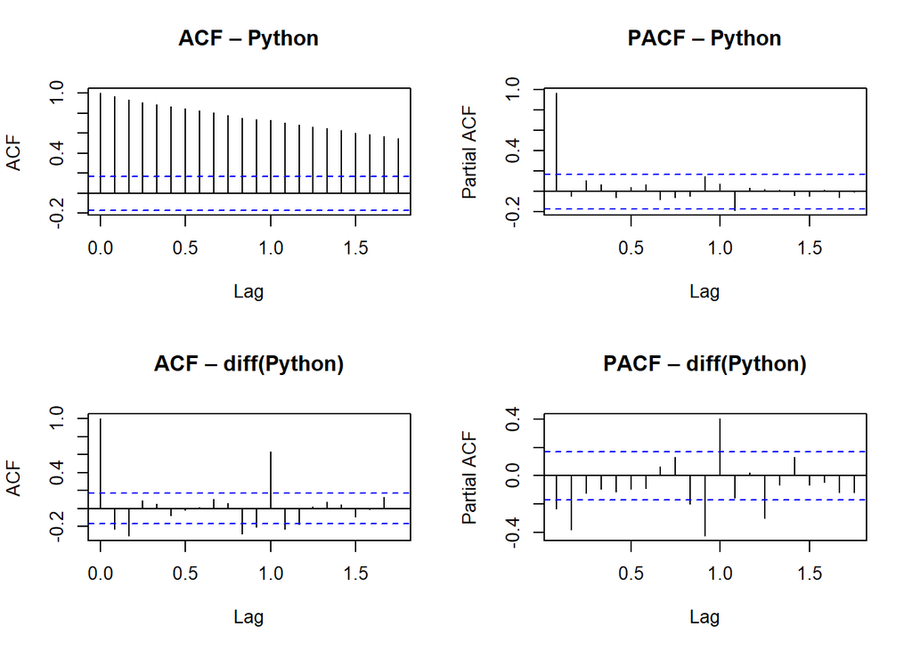

```r
par(mfrow = c(2,2))

acf(python_ts, main = "ACF – Python")
pacf(python_ts, main = "PACF – Python")

acf(diff(python_ts), main = "ACF – diff(Python)")
pacf(diff(python_ts), main = "PACF – diff(Python)")
```

**Shrnutí**:

- Původní řada: ACF pomalu klesá → nestacionární, potvrzuje trend.
- Po diferenciaci: ACF má výrazný lag 1, PACF také → vhodné modely ARIMA(1,1,1) nebo blízké alternativy.

## 4. Výběr vhodných modelů

Na základě předchozí analýzy ACF a PACF a dekompozice řady přistupujeme k manuální konstrukci modelu. Zaměříme se přitom na časovou řadu dotazů na Python (R má velmi podobný průběh). Nejprve však data logaritmujeme, abychom stabilizovali rostoucí rozptyl (heteroskedasticitu), který jsme pozorovali v grafické analýze.Fragment kódu

**Kód**

```r
# Logaritmická transformace pro stabilizaci rozptylu
python_log <- log(python_ts)
```

**Odůvodnění volby parametrů modelu SARIMA**

Naše vizuální analýza ACF a PACF (po diferenciaci) ukázala významné hodnoty na lagu 1,2 (a to záporné) a na sezónním lagu 12. To nás vede k následující volbě parametrů pro výchozí model SARIMA(p,d,q)(P,D,Q)[12]:

- **Trend (**$d=1$): Původní časová řada vykazovala jasný rostoucí trend a nestacionaritu. Aplikace první diference vedla k odstranění nestacionarity, což potvrdil Augmented Dickey-Fullerův test (p-hodnota $< 0.01$). Navíc graf ACF diferencované řady ukazuje na lagu 1 a 2 významné záporné hodnoty. Tento jev je v literatuře považován za varovný signál proti dalšímu diferencování (riziko tzv. *over-differencing*). Na základě těchto statistických i vizuálních testů proto fixujeme řád diferenciace na **$d=1$**.
- **Sezónnost (**$D=1, s=12$): Časová řada vykazuje zřetelnou roční cykličnost. Klíčovým indikátorem je statisticky významná kladná hodnota autokorelační funkce (ACF) na lagu 12, která přetrvává i po provedení první diference. Tento vzor indikuje přítomnost tzv. stochastické sezónnosti, kterou je nutné modelovat aplikací sezónní diference ($D=1$) s periodou $s=12$.
- Nesezónní struktura ($p=1, q=2$):

  Rozhodování o řádech AR a MA vychází z chování autokorelačních funkcí.
  - **MA část (**$q=2$): Graf ACF vykazuje na prvních dvou lazích statisticky významné záporné hodnoty, po kterých následuje pokles do pásma nevýznamnosti (useknutí). Tento vzor je charakteristický pro proces klouzavých průměrů druhého řádu ($q=2$).
  - **AR část (**$p=1$): Graf parciální autokorelace (PACF) nevykazuje ostré useknutí po prvním lagu, ale spíše pozvolnější doznívání, což naznačuje, že čistý MA model by nemusel být dostačující. Proto volíme smíšený model a přidáváme autoregresní člen prvního řádu ($p=1$), abychom zachytili případnou setrvačnost časové řady.
- **Sezónní struktura (**$P=1, Q=1$): Na sezónních lazích (zejména lag 12) pozorujeme v grafech autokorelačních funkcí statisticky významné hodnoty. Vzhledem k tomu, že jednoznačná identifikace čistého sezónního AR nebo MA procesu je vizuálně obtížná, volíme pro startovací model smíšenou strukturu. Zahrnujeme tedy sezónní autoregresní člen ($P=1$) i sezónní klouzavý průměr ($Q=1$), abychom zachytili komplexní vazby mezi stejnými měsíci v po sobě jdoucích letech.

Tímto postupem získáváme startovací model SARIMA(1,1,2)(1,1,1)[12].

## 5. Odhad a optimalizace modelů

Nyní tento model odhadneme a provedeme testování statistické významnosti jeho koeficientů. Naším cílem je najít nejjednodušší možný model , proto zkontrolujeme, zda jsou všechny parametry skutečně potřeba.

**Kód**

```r
# Odhad modelu SARIMA(1,1,2)(1,1,1)[12]
# Volba q=2 vychází z pozorování ACF (lag 1, 2)
fit_manual <- Arima(python_log,
                    order = c(1, 1, 2),
                    seasonal = c(1, 1, 1))

print("=== ANALÝZA KOEFICIENTŮ (Startovací model) ===")
```

```
[1] "=== ANALÝZA KOEFICIENTŮ (Startovací model) ==="
```

**Kód**

```r
print(fit_manual)
```

```
Series: python_log
ARIMA(1,1,2)(1,1,1)[12]

Coefficients:
         ar1      ma1     ma2    sar1     sma1
      0.9935  -0.9597  0.0068  0.2370  -0.7617
s.e.  0.0132   0.1003  0.1011  0.1784   0.1652

sigma^2 = 0.003171:  log likelihood = 173.08
AIC=-334.17   AICc=-333.42   BIC=-317.49
```

### Kritická analýza: Jednotkové kořeny a redundance

Při pohledu na odhadnuté parametry narážíme na závažný strukturální problém, který indikuje špatnou specifikaci řádu diferenciace.

1. **AR část (Jednotkový kořen):** Parametr **ar1** dosahuje hodnoty **0.9935**. To indikuje nestacionaritu a snahu modelu suplovat chybějící diferenciaci ($Y_t - Y_{t-1}$).
2. **MA část (Hranice invertibility):** Současně parametr **ma1** dosahuje hodnoty **-0.9597**, což je velmi blízko hranice invertibility (-1).

Tato situace, kdy mají AR a MA kořeny téměř shodnou absolutní hodnotu, ale opačný vliv, se nazývá **redundance parametrů** (parameter cancellation). Model je nestabilní, protože AR a MA složky se vzájemně “perou” – AR složka se snaží trend vytvořit, zatímco silná MA složka se ho snaží kompenzovat.

Závěr:

Jediným čistým řešením této patové situace je zvýšení řádu diferenciace na $d=2$. Tím se jednotkový kořen z AR části “vyjme” a převede se na pevnou součást modelu (druhou diferenci), čímž se uvolní napětí v parametrech a model se stane stabilním.

Jelikož se parametr `ar1` choval jako diference, provedeme tuto změnu explicitně:

1. Zvýšíme řád diferenciace z $d=1$ na $d=2$.
2. Vyloučíme problematický autoregresní člen (snížíme $p$ z 1 na 0), protože jeho roli převzala druhá diference.
3. Strukturu klouzavých průměrů ($q=2$), kterou jsme odvodili z grafu ACF (záporné lagy), ponecháme.
4. Sezónní část ponecháme v původním nastavení $(1,1,1)$, abychom zachovali konzistenci.

Definujeme tedy nový manuální model: $SARIMA(0,2,2)(1,1,1)_{12}$.

**Kód**

```r
# Nový manuální model:
# - p=0 (odstranili jsme AR kořen)
# - d=2 (přidali jsme diferenci)
# - q=2 (ponechali jsme z ACF)
fit_manual_d2 <- Arima(python_log,
                       order = c(0, 2, 2),
                       seasonal = c(1, 1, 1))

print("=== MANUÁLNÍ MODEL S d=2 (0,2,2)(1,1,1) ===")
```

```
[1] "=== MANUÁLNÍ MODEL S d=2 (0,2,2)(1,1,1) ==="
```

**Kód**

```r
print(fit_manual_d2)
```

```
Series: python_log
ARIMA(0,2,2)(1,1,1)[12]

Coefficients:
         ma1     ma2    sar1     sma1
      -0.963  0.0158  0.2232  -0.7405
s.e.   0.101  0.1017  0.1800   0.1654

sigma^2 = 0.003178:  log likelihood = 166.71
AIC=-323.43   AICc=-322.89   BIC=-309.57
```

**Kód**

```r
# Test významnosti parametrů nového modelu
t_stat_d2 <- fit_manual_d2$coef / sqrt(diag(fit_manual_d2$var.coef))
print(data.frame(Koeficient = names(fit_manual_d2$coef),
                 t_statistika = t_stat_d2,
                 Vyznamny = abs(t_stat_d2) > 1.96))
```

```
     Koeficient t_statistika Vyznamny
ma1         ma1   -9.5340696     TRUE
ma2         ma2    0.1551043    FALSE
sar1       sar1    1.2402200    FALSE
sma1       sma1   -4.4767854     TRUE
```

Analýza statistické významnosti parametrů modelu $SARIMA(0,2,2)(1,1,1)_{12}$ odhalila možnosti pro další zjednodušení:

Parametr ma2: T-statistika indikuje nevýznamnost ($0.15 < 1.96$). Ačkoliv vizuální analýza původně naznačovala potřebu druhého řádu MA, silnější diferenciace ($d=2$) pravděpodobně změnila autokorelační strukturu reziduí natolik, že druhý lag již není nutné explicitně modelovat.Parametr sar1: Sezónní autoregresní složka se opět ukázala jako nadbytečná (t-statistika 1.24).

V souladu s touto nalýzou tyto parametry odstraňujeme a definujeme náš finální manuální model ve tvaru $SARIMA(0,2,1)(0,1,1)_{12}$.

**Kód**

```r
# Finální manuální model (po redukci nevýznamných parametrů)
# Odstraňujeme ma2 (q=2 -> q=1)
# Odstraňujeme sar1 (P=1 -> P=0)
# Stále držíme d=2, protože to vyžaduje trend!
fit_manual_final <- Arima(python_log,
                          order = c(0, 2, 1),
                          seasonal = c(0, 1, 1))

print("=== FINÁLNÍ MANUÁLNÍ MODEL (0,2,1)(0,1,1) ===")
```

```
[1] "=== FINÁLNÍ MANUÁLNÍ MODEL (0,2,1)(0,1,1) ==="
```

**Kód**

```r
print(fit_manual_final)
```

```
Series: python_log
ARIMA(0,2,1)(0,1,1)[12]

Coefficients:
          ma1     sma1
      -0.9527  -0.5472
s.e.   0.0345   0.1165

sigma^2 = 0.003204:  log likelihood = 165.91
AIC=-325.82   AICc=-325.61   BIC=-317.51
```

**Kód**

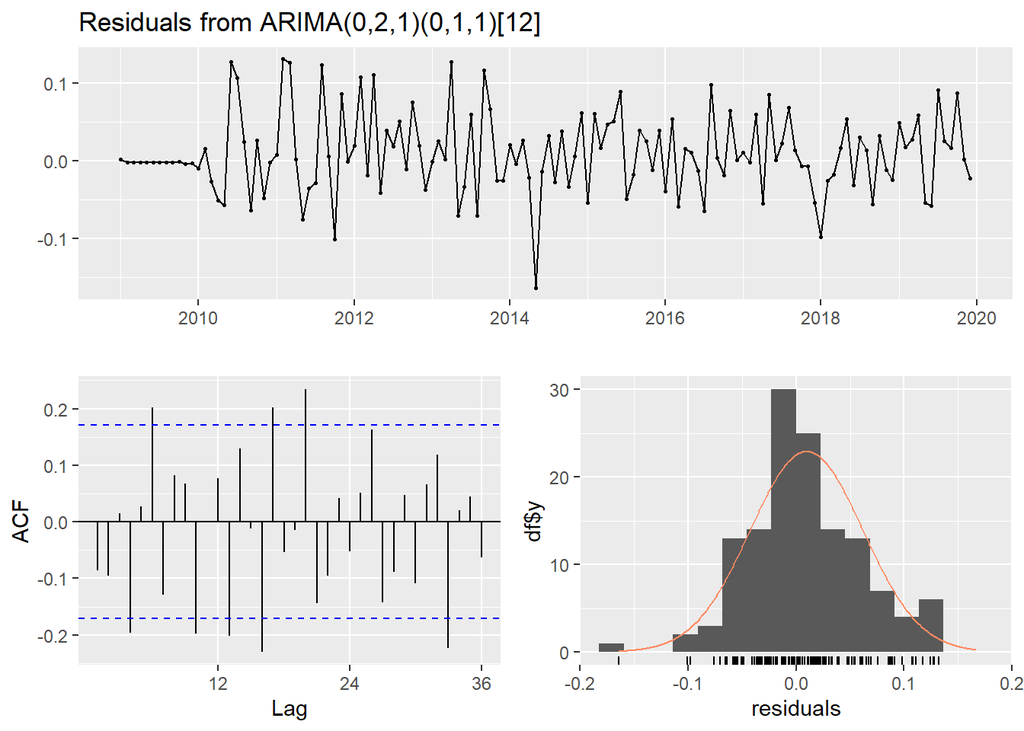

```
    Ljung-Box test

data:  Residuals from ARIMA(0,2,1)(0,1,1)[12]
Q* = 61.51, df = 22, p-value = 1.332e-05

Model df: 2.   Total lags used: 24
```

```r
# Finální kontrola reziduí
checkresiduals(fit_manual_final)
```

Vidíme, že graficky výsledek sice vypadá jako bílý šum, ale box test i korelogram ukazují, že se nám model zvolit manuální nalýzou, tak aby byla residua bílý šum, nepodařilo. Je to dle našho manuálního pohledu nejlepší model který jsme mohli zvolit.  
Pro kontrolu správnosti našeho úsudku nyní necháme algoritmus auto.arima (který minimalizuje informační kritérium AICc), aby našel optimální model sám, a porovnáme ho s naším manuálně redukovaným modelem.

**Kód**

```r
# Automatický návrh (s důrazem na prohledání prostoru)
fit_auto <- auto.arima(python_log, seasonal = TRUE, stepwise = FALSE, approximation = FALSE)

print("=== AUTO ARIMA NÁVRH ===")
```

```
[1] "=== AUTO ARIMA NÁVRH ==="
```

**Kód**

```r
print(fit_auto)
```

```
Series: python_log
ARIMA(0,2,2)(2,0,0)[12]

Coefficients:
          ma1     ma2    sar1    sar2
      -1.0344  0.0657  0.5588  0.2878
s.e.   0.0962  0.0992  0.0949  0.0984

sigma^2 = 0.003331:  log likelihood = 180.86
AIC=-351.72   AICc=-351.24   BIC=-337.38
```

**Kód**

```r
# Srovnání AICc
# Pozor: Porovnáváme náš finální manuální model (fit_manual_final) s automatem
srovnani <- data.frame(
  Model = c("Náš manuální (0,2,1)(0,1,1)", "Auto ARIMA návrh"),
  AICc = c(fit_manual_final$aicc, fit_auto$aicc)
)
print(srovnani)
```

```
                        Model      AICc
1 Náš manuální (0,2,1)(0,1,1) -325.6109
2            Auto ARIMA návrh -351.2357
```

Auto.arima zvolila jiný model s výrazně lepším AICc. Za finální model pro predikci volíme ten s nižším AICc .

**Kód**

```r
# Výběr vítěze pro predikci
# Pokud je náš model srovnatelný (rozdíl AICc < 2) nebo lepší, bereme náš.
if (fit_manual_final$aicc < (fit_auto$aicc + 2)) {
  final_model <- fit_manual_final
  print("Vítěz: Manuální model")
} else {
  final_model <- fit_auto
  print("Vítěz: Auto ARIMA")
}
```

```
[1] "Vítěz: Auto ARIMA"
```

## 6. Diagnostika modelu

Předtím, než model použijeme k predikci, musíme ověřit, zda jeho rezidua (chyby) splňují předpoklady “bílého šumu”. Zkontrolujeme:

- Zda rezidua nevykazují autokorelaci (podstatná informace nezůstala v datech).
- Zda mají normální rozdělení.

**Kód**

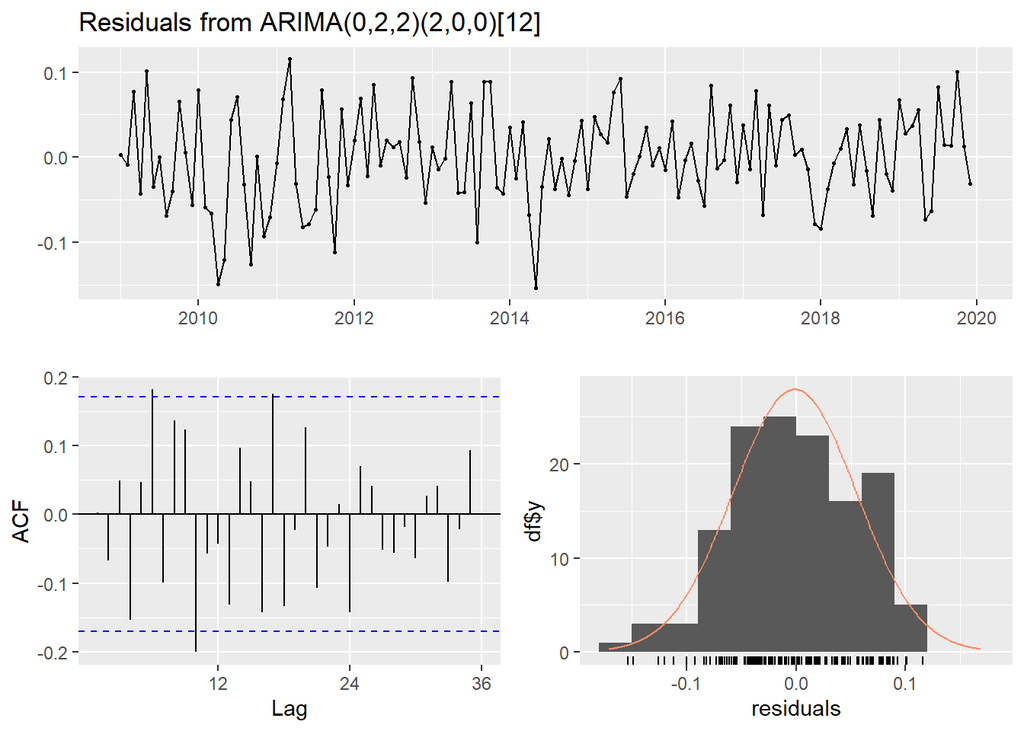

```
    Ljung-Box test

data:  Residuals from ARIMA(0,2,2)(2,0,0)[12]
Q* = 44.909, df = 20, p-value = 0.001135

Model df: 4.   Total lags used: 24
```

```r
# Grafická diagnostika
checkresiduals(final_model)
```

#### Vyhodnocení diagnostiky

Vidíme, že p-hodnota Ljung-Boxova testu není $> 0.05$, a zamítáme nulovou hypotézu. To znamená, že model nedokázal zachytil veškerou strukturu v datech a rezidua nejsou zcela náhodná.

#### Predikce

Provedeme predikci na 12 měsíců dopředu. Je nutné provést zpětnou transformaci (exponenciálu), protože model pracoval s logaritmy.

**Kód**

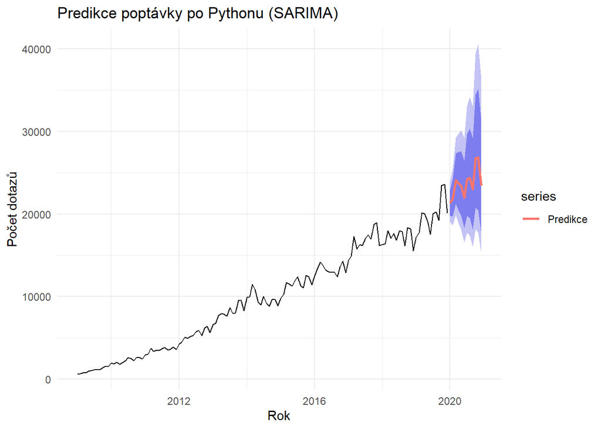

```r
# 1. Predikce v logaritmech
forecast_log <- forecast(final_model, h = 12)

# 2. Zpětná transformace (exp)
forecast_orig <- forecast_log
forecast_orig$mean  <- exp(forecast_log$mean)
forecast_orig$lower <- exp(forecast_log$lower)
forecast_orig$upper <- exp(forecast_log$upper)
forecast_orig$x     <- exp(forecast_log$x)

# 3. Vykreslení
autoplot(forecast_orig) +
  autolayer(forecast_orig$mean, series = "Predikce", size = 1) +
  labs(title = "Predikce poptávky po Pythonu (SARIMA)",
       y = "Počet dotazů",
       x = "Rok") +
  theme_minimal()
```

**Kód**

```r
# Výpis hodnot
print(head(forecast_orig$mean, 12))
```

```
          Jan      Feb      Mar      Apr      May      Jun      Jul      Aug
2020 21331.39 21808.60 24081.68 23699.83 23362.63 21996.58 24210.61 24359.73
          Sep      Oct      Nov      Dec
2020 23014.43 26710.68 26835.25 23453.25
```

### Validace modelu – predikce posledních 24 měsíců

Tuto „pseudo-predikci“ poté porovnáme se skutečnými hodnotami.  
Pokud je model správně nastavený, měl by zachytit alespoň základní trend a sezónní průběh, i když krátkodobé výkyvy se mohou lišit.

**Kód**

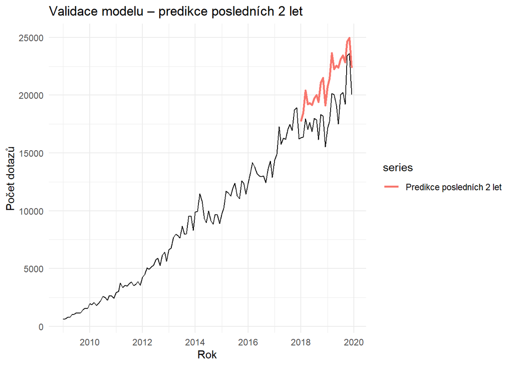

```r
h <- 24

n <- length(python_log)
python_log_train <- head(python_log, n - h)
python_log_test  <- tail(python_log, h)

# stejný typ modelu jako final_model, znovu odhadnutý na zkrácené řadě
model_train <- Arima(python_log_train, model = final_model)

# predikce posledníhch 2 let v logaritmech a zpětná transformace
forecast_log_oos  <- forecast(model_train, h = h)
forecast_oos_mean <- exp(forecast_log_oos$mean)

# graf: celá řada + predikce posledních 2 let
autoplot(exp(python_log)) +
  autolayer(forecast_oos_mean, series = "Predikce posledních 2 let", size = 1) +
  labs(title = "Validace modelu – predikce posledních 2 let",
       y = "Počet dotazů",
       x = "Rok") +
  theme_minimal()
```

# Závěr

## Závěrečné poznámky

Projekt ukazuje postup od přípravy dat až po modelování a predikci pomocí metod ARIMA a jejich variant.